# Data Science for Socioeconomists

Excercise 1 - Introduction

Junbo Huang & Lisa Wegner

# Agenda for today

1. Organisational structures
2. Input: pair programming
3. Groupwork
4. Jupyter Hub
5. Questions?

# Introduction

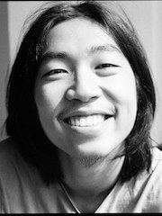

**Junbo Huang**

*research topics:*

- Computational Narrative Understanding
- Natural Language Processing
- Machine Learning

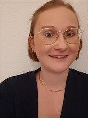

**Lisa Wegner**

*research topics:*

- Applied Economics and Statistics
- Narrative Economics
- Labour Market Policies

# Our concept

exercises take place in rooms WiWi 1005 (Lisa) and WiWi 1004 (Junbo)

1. introduction of tasks for the session and revision of the lecture
2. pair programming - groups of 3 to 4 people
3. peer reviewing - talking about different solutions in the plenum

## Timetable - 2024

| **Date** | **Topic** |
| --- | --- |
| 17/10/2024 | Introduction to this course |
| 24/10/2024 | Introduction to Quarto |
| 31/10/2024 | no tutorial |
| 07/11/2024 | Data and Functions in R |
| 14/11/2024 | Using Principles of Reproducible Research |
| 21/11/2024 | Datavisualization I |
| 28/11/2024 | Datavisualization II - Advanced Graphics |
| 05/12/2024 | Linear regression 1 |
| 12/12/2024 | Linear regression 2 |
| 19/12/2024 | LPM and logistic regression |

## Timetable - 2025

| Week | topic |
| --- | --- |
| 09/01/2025 | Evaluation, cross validation, dimensionality reduction |
| 16/01/2025 | tree based methods |
| 23/01/2025 | tba |
| 30/01/2025 | tba |

# Pair programming?

## Why is pair programming important?<sup>1</sup>

- You’re able to produce **better solutions**
- You’re able to **share knowledge** within your workflow
- Everyone’s an **expert** in something, and everyone has something to teach
- Adds **accountability**: When working closely together no one wants to let their partner(s) down
- Enables you to think and speak about different **alternative approaches**
- Your **problem-solving abilities** are getting stronger
[^1]: https://www.codementor.io/pair-programming

    https://medium.com/kayvan-kaseb/the-importance-of-pair-programming-for-developers-4a8b3325f62f

## Groupwork

- Pair Programming takes place in small groups of 3 to 4 people
- You can choose a group freely but binding - once you’ve joined (e.g.) the *group number 13* you’re in this team for all exercises in these groups

# Using Jupyter Hub

- We work in a shared folder on the Jupyter Hub. You can find it here https://code.min.uni-hamburg.de
- Access can only be granted after the “Korrektur- and Nachmeldephase” ends on 24th of October
- We will still show you how the folder is structured and how this tool works
- Next week you can use it yourself

## Sign in

## Folder structure

## R-Studio online

## “Homework”

- Please sign-in into OpenOlat
- Read the instructions “get started”

# Questions

Is there anything else you would like to know about the exercises?

# Outlook to next tutorial

Next week we will look at:

- Programming with R
- Using Quarto
- Using the JupyterHub

We will do the first group-work-tasks!

Data Science for Socioeconomists